# Moments of K

Alessandro Colombi

27/1/2023

```r
suppressWarnings(suppressPackageStartupMessages(library(GDFMM)))
suppressWarnings(suppressPackageStartupMessages(library(ACutils)))
suppressWarnings(suppressPackageStartupMessages(library(tidyverse)))
suppressWarnings(suppressPackageStartupMessages(library(RColorBrewer)))
suppressWarnings(suppressPackageStartupMessages(library(salso)))
suppressWarnings(suppressPackageStartupMessages(library(wesanderson)))
suppressWarnings(suppressPackageStartupMessages(library(mcclust.ext)))
```

Moments of the Number of Clusters $K$ a priori

# One level

I first consider the case where $d=1$ and $n=100$

```r
n_j = 100
Npoints1 = 30
Npoints2 = 10
gamma_grid  = seq(0.01,2,length.out = Npoints1)
Lambda_grid = seq(1,10,length.out = Npoints2)
Exp_val = matrix(nrow = Npoints1,ncol = Npoints2)
Var = matrix(nrow = Npoints1,ncol = Npoints2)

for(i in 1:Npoints1 ){
  for(j in 1:Npoints2){
    Moments = Expected_prior(n_j = n_j, gamma = gamma_grid[i], type = "distinct",
                             prior = "Poisson", lambda = Lambda_grid[j])
    Exp_val[i,j] = Moments$Mean
    Var[i,j] = Moments$Variance
  }
}

# Unicode for capital Lambda "\u039B"


Lambda_names = unlist(  lapply( as.list(as.character(round(Lambda_grid, digits = 1))),
                                FUN = function(x){ paste0( "\u039B", "=",x)  }
                              )
                     )

gamma_names = unlist(  lapply( as.list(as.character(round(gamma_grid, digits = 2))),
                                FUN = function(x){ paste0( "γ", "=",x)  }
                              )
                     )

rownames(Exp_val) <- rownames(Var) <- gamma_names
colnames(Exp_val) <- colnames(Var) <- Lambda_names
```

Guardo la media

```r
Exp_val
```

```
##                      Λ=1        Λ=2        Λ=3        Λ=4        Λ=5        Λ=6
## γ=0.01   1.050076   1.099857   1.149348   1.198556   1.247486   1.296143
## γ=0.08   1.319712   1.629538   1.930509   2.223487   2.509204   2.788283
## γ=0.15   1.500070   1.979489   2.441161   2.887358   3.319883   3.740195
## γ=0.22   1.625294   2.222476   2.795952   3.349031   3.884262   4.403656
## γ=0.28   1.714641   2.396969   3.052207   3.684199   4.295862   4.889467
## γ=0.35   1.779764   2.525455   3.242522   3.934936   4.605693   5.257121
## γ=0.42   1.828063   2.621955   3.386929   4.126809   4.844480   5.542190
## γ=0.49   1.864413   2.695620   3.498418   4.276313   5.031964   5.767458
## γ=0.56   1.892116   2.752631   3.585744   4.394551   5.181425   5.948242
## γ=0.63   1.913464   2.797279   3.654993   4.489252   5.302111   6.095217
## γ=0.7    1.930076   2.832613   3.710502   4.565935   5.400645   6.216042
## γ=0.76   1.943117   2.860836   3.755422   4.628628   5.481874   6.316338
## γ=0.83   1.953437   2.883569   3.792082   4.680324   5.549414   6.400308
## γ=0.9    1.961663   2.902019   3.822234   4.723281   5.606006   6.471153
## γ=0.97   1.968265   2.917098   3.847206   4.759227   5.653755   6.531339
## γ=1.04   1.973597   2.929501   3.868021   4.789500   5.694300   6.582793
## γ=1.11   1.977928   2.939764   3.885475   4.815144   5.728929   6.627036
## γ=1.18   1.981464   2.948303   3.900192   4.836987   5.758664   6.665282
## γ=1.25   1.984368   2.955444   3.912664   4.855685   5.784325   6.698506
## γ=1.31   1.986763   2.961446   3.923284   4.871768   5.806572   6.727501
## γ=1.38   1.988747   2.966514   3.932369   4.885663   5.825944   6.752912
## γ=1.45   1.990399   2.970810   3.940173   4.897716   5.842882   6.775272
## γ=1.52   1.991779   2.974469   3.946904   4.908213   5.857747   6.795021
## γ=1.59   1.992937   2.977596   3.952731   4.917389   5.870840   6.812525
## γ=1.66   1.993912   2.980278   3.957794   4.925439   5.882413   6.828092
## γ=1.73   1.994736   2.982588   3.962208   4.932523   5.892675   6.841980
## γ=1.79   1.995435   2.984583   3.966069   4.938777   5.901801   6.854407
## γ=1.86   1.996029   2.986312   3.969457   4.944316   5.909943   6.865558
## γ=1.93   1.996537   2.987815   3.972438   4.949235   5.917225   6.875591
## γ=2      1.996971   2.989125   3.975069   4.953615   5.923757   6.884642
##                      Λ=7        Λ=8        Λ=9        Λ=10
## γ=0.01   1.344533   1.392661   1.440532    1.488150
## γ=0.08   3.061261   3.328601   3.590708    3.847940
## γ=0.15   4.149492   4.548768   4.938864    5.320492
## γ=0.22   4.908825   5.401092   5.881554    6.351137
## γ=0.28   5.466824   6.029407   6.578440    7.114950
## γ=0.35   5.891072   6.509058   7.112334    7.701961
## γ=0.42   6.221736   6.884592   7.531988    8.164970
## γ=0.49   6.484477   7.184407   7.868420    8.537515
## γ=0.56   6.696533   7.427575   8.142451    8.842100
## γ=0.63   6.869932   7.627404   8.368621    9.094443
## γ=0.7    7.013312   7.793469   8.557394    9.305869
## γ=0.76   7.133028   7.932821   8.716495    9.484744
## γ=0.83   7.233844   8.050764   8.851737    9.637376
## γ=0.9    7.319397   8.151349   8.967577    9.768606
## γ=0.97   7.392498   8.237723   9.067477    9.882205
## γ=1.04   7.455353   8.312354   9.154165    9.981148
## γ=1.11   7.509708   8.377207   9.229812   10.067808
## γ=1.18   7.556959   8.433857   9.296167   10.144101
## γ=1.25   7.598236   8.483580   9.354648   10.211584
## γ=1.31   7.634457   8.527417   9.406417   10.271535
## γ=1.38   7.666374   8.566227   9.452434   10.325010
## γ=1.45   7.694610   8.600718   9.493492   10.372891
## γ=1.52   7.719682   8.631483   9.530259   10.415912
## γ=1.59   7.742022   8.659018   9.563292   10.454696
## γ=1.66   7.761992   8.683741   9.593066   10.489768
## γ=1.73   7.779898   8.706007   9.619980   10.521577
## γ=1.79   7.796002   8.726117   9.644380   10.550507
## γ=1.86   7.810525   8.744329   9.666557   10.576886
## γ=1.93   7.823657   8.760866   9.686767   10.600999
## γ=2      7.835560   8.775918   9.705227   10.623093
```

- Valori piccoli di $\gamma$ hanno un certo impatto, che però svanisce al crescere di $\gamma$.
- La soglia da cui in poi $\gamma$ non impatta più, dipende da $\Lambda$, più crece $\Lambda$, più valori di $\gamma$ hanno effetto
- Da quella soglia in poi, $E[K]$ è determinato solo da $\Lambda$

```r
Var
```

```
##                      Λ=1        Λ=2        Λ=3        Λ=4        Λ=5        Λ=6
## γ=0.01  0.0499201 0.09924105  0.1479815  0.1961591   0.243791  0.2908934
## γ=0.08  0.3129654 0.60465424  0.8786261  1.1376329   1.383832  1.6189370
## γ=0.15  0.4838644 0.92172159  1.3241743  1.6985453   2.050038  2.3824498
## γ=0.22  0.6012687 1.13822470  1.6275229  2.0799792   2.502903  2.9014251
## γ=0.28  0.6854568 1.29523189  1.8496337  2.3614449   2.839113  3.2884844
## γ=0.35  0.7478362 1.41409339  2.0204780  2.5804941   3.103022  3.5942121
## γ=0.42  0.7952391 1.50691537  2.1564451  2.7571744   3.317939  3.8449212
## γ=0.49  0.8319820 1.58107716  2.2672944  2.9032462   3.497408  4.0558094
## γ=0.56  0.8609172 1.64135669  2.3592601  3.0261548   3.649952  4.2363991
## γ=0.63  0.8840006 1.69100616  2.4365626  3.1309179   3.781292  4.3930631
## γ=0.7   0.9026156 1.73233176  2.5021971  3.2210943   3.895480  4.5303017
## γ=0.76  0.9177652 1.76702411  2.5583723  3.2993146   3.995510  4.6514358
## γ=0.83  0.9301928 1.79635627  2.6067673  3.3675879   4.083672  4.7590040
## γ=0.9   0.9404586 1.82130782  2.6486901  3.4274896   4.161767  4.8550032
## γ=0.97  0.9489913 1.84264587  2.6851792  3.4802803   4.231242  4.9410399
## γ=1.04  0.9561233 1.86097979  2.7170719  3.5269856   4.293279  5.0184305
## γ=1.11  0.9621149 1.87679940  2.7450520  3.5684508   4.348860  5.0882689
## γ=1.18  0.9671718 1.89050237  2.7696834  3.6053800   4.398805  5.1514755
## γ=1.25  0.9714585 1.90241426  2.7914350  3.6383649   4.443808  5.2088314
## γ=1.31  0.9751067 1.91280351  2.8106998  3.6679059   4.484463  5.2610054
## γ=1.38  0.9782233 1.92189290  2.8278088  3.6944293   4.521276  5.3085736
## γ=1.45  0.9808952 1.92986834  2.8430427  3.7183001   4.554685  5.3520349
## γ=1.52  0.9831935 1.93688572  2.8566402  3.7398319   4.585069  5.3918239
## γ=1.59  0.9851766 1.94307639  2.8688055  3.7592955   4.612757  5.4283203
## γ=1.66  0.9868929 1.94855148  2.8797137  3.7769258   4.638037  5.4618575
## γ=1.73  0.9883826 1.95340532  2.8895158  3.7929269   4.661161  5.4927289
## γ=1.79  0.9896792 1.95771833  2.8983420  3.8074766   4.682349  5.5211937
## γ=1.86  0.9908106 1.96155927  2.9063052  3.8207308   4.701797  5.5474815
## γ=1.93  0.9918003 1.96498710  2.9135036  3.8328259   4.719677  5.5717961
## γ=2     0.9926683 1.96805254  2.9200225  3.8438821   4.736142  5.5943190
##                      Λ=7        Λ=8        Λ=9        Λ=10
## γ=0.01  0.3374818  0.3835711  0.4291757   0.4743092
## γ=0.08  1.8443269  2.0611240  2.2702523   2.4724805
## γ=0.15  2.6986240  3.0007387  3.2904990   3.5692660
## γ=0.22  3.2792730  3.6392440  3.9834967   4.3137395
## γ=0.28  3.7137740  4.1181384  4.5040176   4.8733505
## γ=0.35  4.0585209  4.4993113  4.9192065   5.3203108
## γ=0.42  4.3426565  4.8146123  5.2635277   5.6916264
## γ=0.49  4.5829496  5.0823241  5.5567353   6.0084883
## γ=0.56  4.7898748  5.3138412  5.8111192   6.2840618
## γ=0.63  4.9704214  5.5167465  6.0348392   6.5270699
## γ=0.7   5.1295114  5.6963647  6.2336087   6.7436039
## γ=0.76  5.2707679  5.8566040  6.4116085   6.9381078
## γ=0.83  5.3969553  6.0004386  6.5720110   7.1139433
## γ=0.9   5.5102455  6.1302005  6.7172970   7.2737316
## γ=0.97  5.6123856  6.2477625  6.8494547   7.4195685
## γ=1.04  5.7048073  6.3546588  6.9701101   7.5531641
## γ=1.11  5.7887023  6.4521656  7.0806151   7.6759385
## γ=1.18  5.8650744  6.5413594  7.1821090   7.7890870
## γ=1.25  5.9347783  6.6231569  7.2755628   7.8936282
## γ=1.31  5.9985472  6.6983465  7.3618117   7.9904380
## γ=1.38  6.0570150  6.7676106  7.4415799   8.0802763
## γ=1.45  6.1107326  6.8315442  7.5154992   8.1638065
## γ=1.52  6.1601816  6.8906682  7.5841241   8.2416117
## γ=1.59  6.2057843  6.9454412  7.6479437   8.3142065
## γ=1.66  6.2479132  6.9962686  7.7073911   8.3820477
## γ=1.73  6.2868973  7.0435098  7.7628514   8.4455420
## γ=1.79  6.3230287  7.0874847  7.8146682   8.5050526
## γ=1.86  6.3565669  7.1284787  7.8631486   8.5609056
## γ=1.93  6.3877436  7.1667473  7.9085686   8.6133938
## γ=2     6.4167658  7.2025195  7.9511761   8.6627814
```

- Per quanto riguarda la varianza, l’impatto di $\gamma$ sembra trascurabile rispetto a $\Lambda$, soprattutto per $\gamma>1$.
- In più, la varianza sembra essere sempre simile alla media, cosa che può dato che $\Lambda$ è distribuita con una Poisson. Potrebbe tuttavia essere una limitazione.

## Distribution for $\Lambda$ fixed

Fisso $\Lambda = 4$ e guardo la distribuzione del numero di cluster al variare di $\gamma$

```r
Npoints = 100
Lambda = 4
gamma_grid  = seq(0.03,3,length.out = Npoints)
prob_k = matrix(nrow = Npoints, ncol = n_j)

for(i in 1:Npoints){

  #threshold = 0.995
  for(kk in 1:n_j ){
    prob_k[i,kk] = p_distinct_prior(k = kk, n_j = n_j,
                                    gamma = gamma_grid[i],
                                    prior = "Poisson",
                                    lambda = Lambda)
    #if(sum(prob_k)>=threshold)
      #break
  }
}
```

La curva nera è la prima, quella con $\gamma$ minore

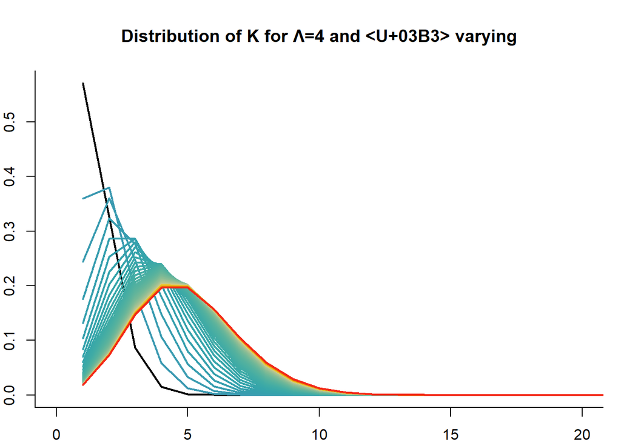

```r
par(mar = c(2,2,4,1), bty = "l")
matplot( t(prob_k), type = "l", lwd = 2,xlim = c(0,20),lty = 1,
          col = c("black",hcl.colors(n=Npoints, palette = "Zissou 1")),
          main = paste0(  paste0( "Distribution of K for \u039B=4 and γ varying") ))
```

Rifaccio con $\Lambda = 20$

```r
Npoints = 100
Lambda = 20
gamma_grid  = seq(0.01,2,length.out = Npoints)
prob_k2 = matrix(nrow = Npoints, ncol = n_j)

for(i in 1:Npoints){

  #threshold = 0.995
  for(kk in 1:n_j ){
    prob_k2[i,kk] = p_distinct_prior(k = kk, n_j = n_j,
                                    gamma = gamma_grid[i],
                                    prior = "Poisson",
                                    lambda = Lambda)
    #if(sum(prob_k)>=threshold)
      #break
  }
}
```

La curva nera è la prima, quella con $\gamma$ minore

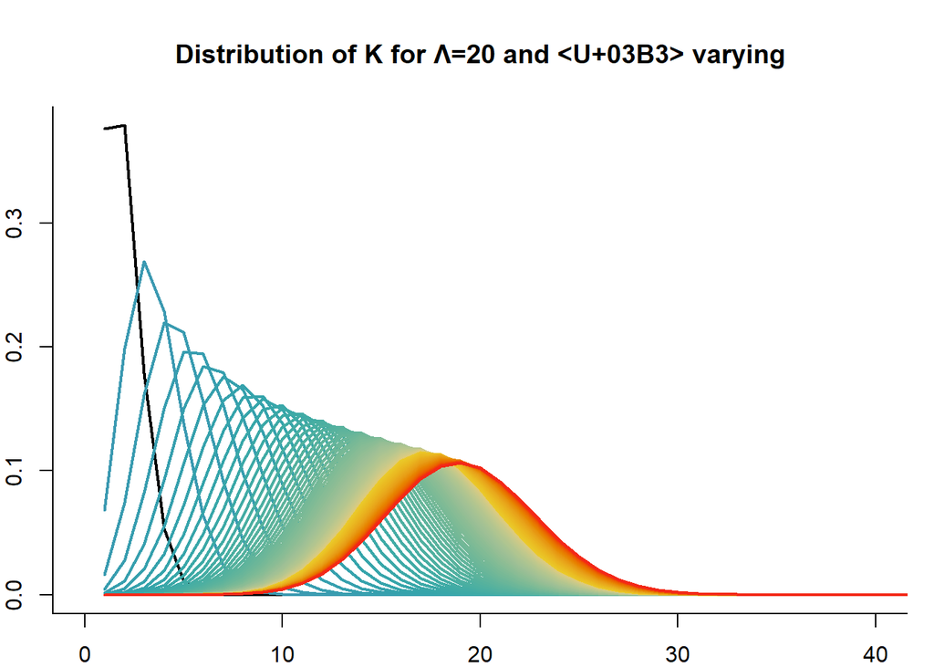

```r
par(mar = c(2,2,4,1), bty = "l")
matplot( t(prob_k2), type = "l", lwd = 2,xlim = c(0,40), lty = 1,
         col = c("black",hcl.colors(n=Npoints, palette = "Zissou 1")),
         main = paste0(  paste0( "Distribution of K for \u039B=20 and γ varying") ))
```

La variabilità sembra essere sempre simile

## Distribution for $\gamma$ fixed

Ora faccio l’esperimento inverso, tengo fisso $\gamma$ e faccio variare $\Lambda$.

### gamma = 2

```r
Npoints = 20
gamma = 2
Lambda_grid  = seq(1,20,length.out = Npoints)
prob_k3 = matrix(nrow = Npoints, ncol = n_j)

for(i in 1:Npoints){

  #threshold = 0.995
  for(kk in 1:n_j ){
    prob_k3[i,kk] = p_distinct_prior(k = kk, n_j = n_j,
                                     gamma = gamma,
                                     prior = "Poisson",
                                     lambda = Lambda_grid[i])
    #if(sum(prob_k)>=threshold)
      #break
  }
}
```

La curva nera è la prima, quella con $\Lambda$ minore. Ogni curva, corrisponde ad aumentare $\Lambda$ di 1.

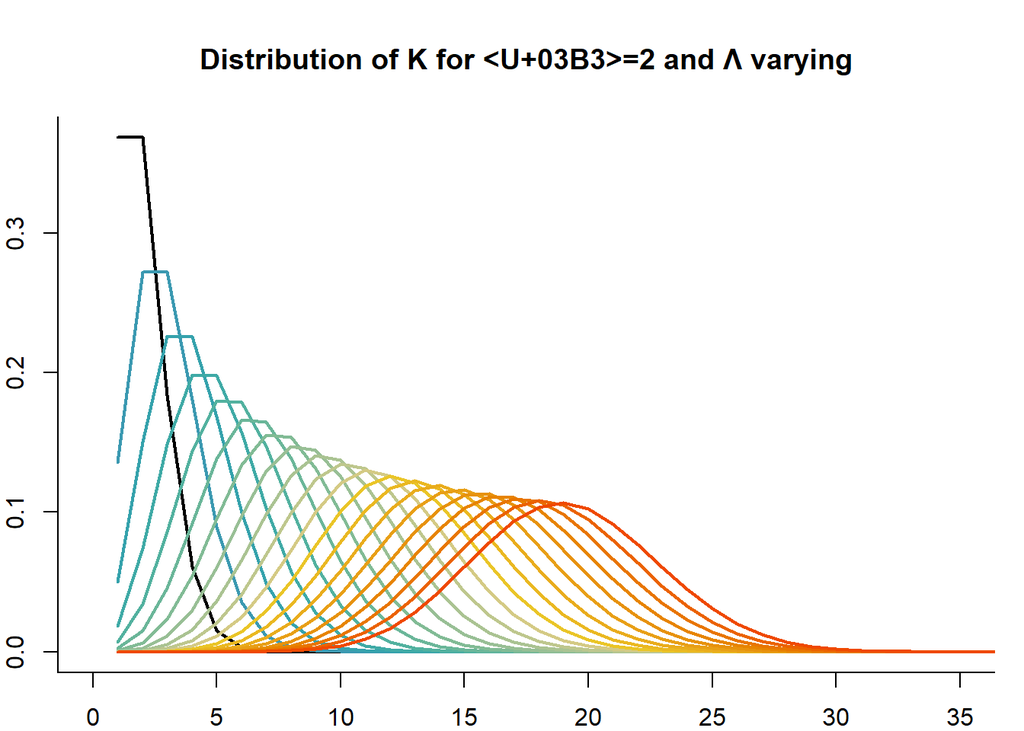

```r
par(mar = c(2,2,4,1), bty = "l")
matplot( t(prob_k3), type = "l", lwd = 2,xlim = c(0,35),lty = 1,
         col = c("black",hcl.colors(n=Npoints, palette = "Zissou 1")),
         main = paste0(  paste0( "Distribution of K for γ=2 and \u039B varying") ))
```

### gamma = 0.1

Ripeto lo stesso esperimento abbassando il valore di $\gamma$. Ogni curva, corrisponde ad aumentare $\Lambda$ di 1.

```r
Npoints = 20
gamma = 0.1
Lambda_grid  = seq(1,20,length.out = Npoints)
prob_k3 = matrix(nrow = Npoints, ncol = n_j)

for(i in 1:Npoints){

  #threshold = 0.995
  for(kk in 1:n_j ){
    prob_k3[i,kk] = p_distinct_prior(k = kk, n_j = n_j,
                                     gamma = gamma,
                                     prior = "Poisson",
                                     lambda = Lambda_grid[i])
    #if(sum(prob_k)>=threshold)
      #break
  }
}
```

La curva nera è la prima, quella con $\Lambda$ minore

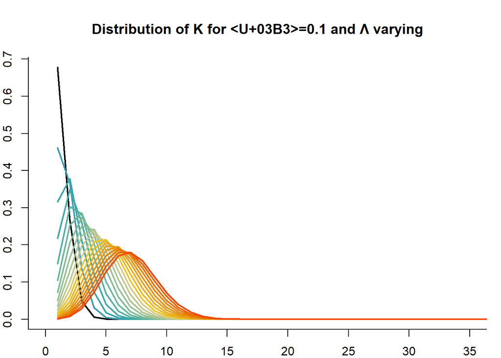

```r
par(mar = c(2,2,4,1), bty = "l")
matplot( t(prob_k3), type = "l", lwd = 2,xlim = c(0,35), lty = 1,
         col = c("black",hcl.colors(n=Npoints, palette = "Zissou 1")),
         main = paste0(  paste0( "Distribution of K for γ=0.1 and \u039B varying") ))
```

Al crescere di $\Lambda$ le curve si spostano ma molto più lentamente.

**CONCLUSIONI**

# Two levels

I repeat the experiment when $d=2$. Now, the process parameters are $\gamma_1,\gamma_2, \Lambda$.

I consider an unbalanced number of points in the two levels, $n=(100,50)$.

## Grid for fixed Lambda

Fisso $\Lambda = 6$

```r
n_j = c(100,50)
Lambda = 6

Npoints = 20
gamma1_grid  = seq(0.01,1,length.out = Npoints)
gamma2_grid  = seq(0.01,1,length.out = Npoints)

#Lambda_grid = seq(2,10,length.out = Npoints)

Exp_val = matrix(nrow = Npoints,ncol = Npoints)
Var     = matrix(nrow = Npoints,ncol = Npoints)

for(i in 1:Npoints){
  for(j in 1:Npoints){
    Moments = Expected_prior(n_j = n_j, gamma = c(gamma1_grid[i],gamma2_grid[j]),
                             type = "distinct",
                             prior = "Poisson", lambda = Lambda )
    Exp_val[i,j] = Moments$Mean
    Var[i,j]     = Moments$Variance
  }
}



gamma1_names = unlist(  lapply( as.list(as.character(round(gamma1_grid, digits = 2))),
                                FUN = function(x){ paste0( "γ1", "=",x)  }
                              )
                     )
gamma2_names = unlist(  lapply( as.list(as.character(round(gamma2_grid, digits = 2))),
                                FUN = function(x){ paste0( "γ2", "=",x)  }
                              )
                     )

rownames(Exp_val) <- rownames(Var) <- gamma1_names
colnames(Exp_val) <- colnames(Var) <- gamma2_names
```

Guardo la media

```r
Exp_val
```

```
##                γ2=0.01 γ2=0.06 γ2=0.11 γ2=0.17
## γ1=0.01       2.298289       3.147278       3.744186       4.193657
## γ1=0.06       3.283839       3.954651       4.426190       4.781238
## γ1=0.11       3.969643       4.516385       4.900589       5.189852
## γ1=0.17       4.478482       4.933163       5.252560       5.493006
## γ1=0.22       4.870657       5.254395       5.523856       5.726689
## γ1=0.27       5.180888       5.508522       5.738499       5.911593
## γ1=0.32       5.431096       5.713497       5.911647       6.060770
## γ1=0.37       5.635990       5.881363       6.053467       6.182974
## γ1=0.43       5.805873       6.020558       6.171080       6.284335
## γ1=0.48       5.948205       6.137189       6.269641       6.369290
## γ1=0.53       6.068526       6.235793       6.352981       6.441137
## γ1=0.58       6.171037       6.319809       6.424002       6.502374
## γ1=0.64       6.258979       6.391892       6.484944       6.554930
## γ1=0.69       6.334891       6.454121       6.537563       6.600315
## γ1=0.74       6.400784       6.508141       6.583248       6.639726
## γ1=0.79       6.458272       6.555276       6.623116       6.674125
## γ1=0.84       6.508661       6.596594       6.658069       6.704287
## γ1=0.9        6.553016       6.632968       6.688844       6.730850
## γ1=0.95       6.592216       6.665117       6.716049       6.754334
## γ1=1          6.626987       6.693637       6.740186       6.775174
##                γ2=0.22 γ2=0.27 γ2=0.32 γ2=0.37
## γ1=0.01       4.546091       4.830156       5.063825       5.259116
## γ1=0.06       5.059635       5.284033       5.468629       5.622916
## γ1=0.11       5.416667       5.599497       5.749910       5.875638
## γ1=0.17       5.681544       5.833528       5.958575       6.063111
## γ1=0.22       5.885735       6.013952       6.119454       6.207660
## γ1=0.27       6.047320       6.156745       6.246792       6.322086
## γ1=0.32       6.177702       6.271979       6.349568       6.414452
## γ1=0.37       6.284524       6.366406       6.433799       6.490163
## γ1=0.43       6.373142       6.444752       6.503697       6.553001
## γ1=0.48       6.447429       6.510441       6.562312       6.605704
## γ1=0.53       6.510264       6.566012       6.611908       6.650304
## γ1=0.58       6.563829       6.613393       6.654201       6.688345
## γ1=0.64       6.609809       6.654071       6.690518       6.721015
## γ1=0.69       6.649522       6.689211       6.721895       6.749247
## γ1=0.74       6.684014       6.719737       6.749158       6.773781
## γ1=0.79       6.714123       6.746390       6.772964       6.795208
## γ1=0.84       6.740530       6.769768       6.793851       6.814010
## γ1=0.9        6.763789       6.790363       6.812253       6.830579
```

[output cut: 50 more lines]

```
## γ1=0.27       6.672603      6.692907       6.711246    6.727871
## γ1=0.32       6.716674      6.734194       6.750022    6.764371
## γ1=0.37       6.752842      6.768082       6.781852    6.794337
## γ1=0.43       6.782899      6.796248       6.808311    6.819250
## γ1=0.48       6.808142      6.819906       6.830538    6.840180
## γ1=0.53       6.829534      6.839957       6.849379    6.857924
## γ1=0.58       6.847805      6.857086       6.865475    6.873086
## γ1=0.64       6.863518      6.871818       6.879322    6.886130
## γ1=0.69       6.877116      6.884569       6.891308    6.897423
## γ1=0.74       6.888949      6.895666       6.901741    6.907254
## γ1=0.79       6.899298      6.905374       6.910869    6.915856
## γ1=0.84       6.908392      6.913905       6.918891    6.923418
## γ1=0.9        6.916416      6.921434       6.925972    6.930093
## γ1=0.95       6.923526      6.928105       6.932247    6.936009
## γ1=1          6.929847      6.934037       6.937829    6.941271
```

- L’impatto di $\gamma_1$ e $\gamma_2$ è un’estensione di quello che abbiamo visto nel caso $d=1$.
- $E[K]$ cresce più velocemente con $\gamma_1$ che con $\gamma_2$, ovvero con il livello più numeroso.
- Un’importante differenza è che ora l’upper bound per $E[K]$ sembra essere $\Lambda+1$ e non solo $\Lambda$

Guardo anche la varianza

```r
Var
```

```
##                γ2=0.01 γ2=0.06 γ2=0.11 γ2=0.17
## γ1=0.01      0.6044881       1.404958       1.929747       2.314154
## γ1=0.06      1.5522425       2.213090       2.644915       2.962039
## γ1=0.11      2.1842985       2.751590       3.122927       3.396627
## γ1=0.17      2.6513889       3.150621       3.478376       3.720721
## γ1=0.22      3.0177475       3.464380       3.758518       3.976551
## γ1=0.27      3.3164174       3.720581       3.987530       4.185788
## γ1=0.32      3.5665122       3.935270       4.179478       4.361108
## γ1=0.37      3.7800362       4.118572       4.343290       4.510607
## γ1=0.43      3.9650112       4.277291       4.485007       4.639792
## γ1=0.48      4.1270664       4.416228       4.608916       4.752592
## γ1=0.53      4.2703115       4.538909       4.718180       4.851914
## γ1=0.58      4.3978459       4.648005       4.815205       4.939980
## γ1=0.64      4.5120709       4.745592       4.901868       5.018521
## γ1=0.69      4.6148897       4.833321       4.979662       5.088921
## γ1=0.74      4.7078393       4.912526       5.049798       5.152300
## γ1=0.79      4.7921807       4.984306       5.113269       5.209578
## γ1=0.84      4.8689630       5.049573       5.170904       5.261520
## γ1=0.9       4.9390685       5.109093       5.223398       5.308771
## γ1=0.95      5.0032469       5.163521       5.271341       5.351875
## γ1=1         5.0621406       5.213413       5.315239       5.391297
##                γ2=0.22 γ2=0.27 γ2=0.32 γ2=0.37
## γ1=0.01       2.614492       2.859300       3.064887       3.241374
## γ1=0.06       3.210663       3.413930       3.585019       3.732117
## γ1=0.11       3.611877       3.788243       3.936882       4.064752
## γ1=0.17       3.911732       4.068431       4.200554       4.314200
## γ1=0.22       4.148647       4.289904       4.408995       4.511373
## γ1=0.27       4.342411       4.470980       4.579325       4.672390
## γ1=0.32       4.504663       4.622482       4.721704       4.806856
## γ1=0.37       4.642876       4.751391       4.842712       4.921007
## γ1=0.43       4.762157       4.862498       4.946875       5.019148
## γ1=0.48       4.866162       4.959242       5.037451       5.104380
## γ1=0.53       4.957607       5.044182       5.116870       5.179019
## γ1=0.58       5.038567       5.119279       5.186993       5.244840
## γ1=0.64       5.110668       5.186064       5.249275       5.303233
## γ1=0.69       5.175203       5.245763       5.304880       5.355306
## γ1=0.74       5.233223       5.299367       5.354749       5.401957
## γ1=0.79       5.285590       5.347690       5.399655       5.443922
## γ1=0.84       5.333020       5.391407       5.440238       5.481810
## γ1=0.9        5.376115       5.431085       5.477035       5.516132
```

[output cut: 50 more lines]

```
## γ1=0.27       5.161943      5.195157       5.225906    5.254453
## γ1=0.32       5.252501      5.282539       5.310321    5.336087
## γ1=0.37       5.328768      5.356086       5.381327    5.404717
## γ1=0.43       5.393807      5.418764       5.441805    5.463139
## γ1=0.48       5.449836      5.472728       5.493845    5.513383
## γ1=0.53       5.498517      5.519586       5.539008    5.556965
## γ1=0.58       5.541121      5.560571       5.578490    5.595047
## γ1=0.64       5.578642      5.596648       5.613226    5.628535
## γ1=0.69       5.611871      5.628582       5.643958    5.658151
## γ1=0.74       5.641445      5.656989       5.671284    5.684472
## γ1=0.79       5.667883      5.682372       5.695691    5.707973
## γ1=0.84       5.691612      5.705145       5.717579    5.729040
## γ1=0.9        5.712989      5.725651       5.737281    5.747997
## γ1=0.95       5.732311      5.744180       5.755077    5.765114
## γ1=1          5.749830      5.760973       5.771201    5.780618
```

## Grid for fixed $\gamma_1=\gamma_2$

```r
n_j = c(100,50)

Npoints1 = 30
Npoints2 = 10
Lambda_grid  = seq(1,10,length.out = Npoints2)
gamma_grid  = seq(0.01,1,length.out = Npoints1)

#Lambda_grid = seq(2,10,length.out = Npoints)

Exp_val = matrix(nrow = Npoints1,ncol = Npoints2)
Var     = matrix(nrow = Npoints1,ncol = Npoints2)

for(i in 1:Npoints1){
  for(j in 1:Npoints2){
    Moments = Expected_prior(n_j = n_j, gamma = c(gamma_grid[i],gamma_grid[i]),
                             type = "distinct",
                             prior = "Poisson", lambda = Lambda_grid[j] )
    Exp_val[i,j] = Moments$Mean
    Var[i,j]     = Moments$Variance
  }
}



Lambda_names = unlist(  lapply( as.list(as.character(round(Lambda_grid, digits = 1))),
                                FUN = function(x){ paste0( "\u039B", "=",x)  }
                              )
                     )
gamma2_names = unlist(  lapply( as.list(as.character(round(gamma_grid, digits = 2))),
                                FUN = function(x){ paste0( "γ1=γ2", "=",x)  }
                              )
                     )

rownames(Exp_val) <- rownames(Var) <- gamma2_names
colnames(Exp_val) <- colnames(Var) <- Lambda_names
```

Guardo la media

```r
Exp_val
```

```
##                                 Λ=1        Λ=2        Λ=3        Λ=4        Λ=5
## γ1=γ2=0.01   1.425578   1.697996   1.893426   2.048116   2.179987
## γ1=γ2=0.04   1.580824   2.045153   2.448080   2.816018   3.162199
## γ1=γ2=0.08   1.689292   2.285657   2.829525   3.340661   3.829274
## γ1=γ2=0.11   1.766623   2.456896   3.100905   3.713767   4.303598
## γ1=γ2=0.15   1.822683   2.581462   3.298960   3.986905   4.651851
## γ1=γ2=0.18   1.863902   2.673680   3.446450   4.191381   4.913801
## γ1=γ2=0.21   1.894587   2.742967   3.558124   4.347244   5.114656
## γ1=γ2=0.25   1.917679   2.795692   3.643877   4.467851   5.271117
## γ1=γ2=0.28   1.935228   2.836266   3.710530   4.562383   5.394634
## γ1=γ2=0.32   1.948682   2.867801   3.762892   4.637308   5.493273
## γ1=γ2=0.35   1.959079   2.892530   3.804420   4.697280   5.572844
## γ1=γ2=0.39   1.967175   2.912081   3.837636   4.745708   5.637612
## γ1=γ2=0.42   1.973521   2.927653   3.864412   4.785125   5.690755
## γ1=γ2=0.45   1.978528   2.940141   3.886150   4.817440   5.734679
## γ1=γ2=0.49   1.982501   2.950220   3.903912   4.844109   5.771226
## γ1=γ2=0.52   1.985672   2.958402   3.918515   4.866251   5.801820
## γ1=γ2=0.56   1.988216   2.965081   3.930586   4.884741   5.827578
## γ1=γ2=0.59   1.990267   2.970561   3.940619   4.900260   5.849376
## γ1=γ2=0.62   1.991929   2.975080   3.948997   4.913351   5.867914
## γ1=γ2=0.66   1.993281   2.978824   3.956027   4.924445   5.883752
## γ1=γ2=0.69   1.994385   2.981939   3.961951   4.933887   5.897341
## γ1=γ2=0.73   1.995292   2.984541   3.966964   4.941956   5.909048
## γ1=γ2=0.76   1.996038   2.986724   3.971222   4.948879   5.919171
## γ1=γ2=0.8    1.996656   2.988561   3.974853   4.954839   5.927958
## γ1=γ2=0.83   1.997168   2.990114   3.977961   4.959990   5.935610
## γ1=γ2=0.86   1.997594   2.991431   3.980628   4.964455   5.942296
## γ1=γ2=0.9    1.997950   2.992551   3.982927   4.968338   5.948155
## γ1=γ2=0.93   1.998249   2.993507   3.984912   4.971725   5.953306
## γ1=γ2=0.97   1.998500   2.994325   3.986633   4.974689   5.957847
## γ1=γ2=1      1.998711   2.995027   3.988129   4.977289   5.961861
##                                 Λ=6        Λ=7        Λ=8        Λ=9
## γ1=γ2=0.01   2.298289   2.408024   2.512027   2.611988
## γ1=γ2=0.04   3.493595   3.814100   4.126025   4.430831
## γ1=γ2=0.08   4.300984   4.759117   5.205794   5.642466
## γ1=γ2=0.11   4.875093   5.431198   5.973906   6.504658
## γ1=γ2=0.15   5.297775   5.927297   6.542270   7.144089
## γ1=γ2=0.18   5.617082   6.303536   6.974855   7.632351
## γ1=γ2=0.21   5.863204   6.594905   7.311278   8.013526
## γ1=γ2=0.25   6.056052   6.824393   7.577478   8.316387
```

[output cut: 38 more lines]

```
## γ1=γ2=0.52   10.304006
## γ1=γ2=0.56   10.374857
## γ1=γ2=0.59   10.436431
## γ1=γ2=0.62   10.490197
## γ1=γ2=0.66   10.537351
## γ1=γ2=0.69   10.578874
## γ1=γ2=0.73   10.615578
## γ1=γ2=0.76   10.648141
## γ1=γ2=0.8    10.677125
## γ1=γ2=0.83   10.703008
## γ1=γ2=0.86   10.726190
## γ1=γ2=0.9    10.747012
## γ1=γ2=0.93   10.765765
## γ1=γ2=0.97   10.782699
## γ1=γ2=1      10.798027
```

Il comportamento è simile a prima ma lo spazio di manovra sembra molto più limitato, i valori convergono molto più velocemente all’upper bound dato da $E[K]$.

Guardo la varianza

```r
Var
```

```
##                                 Λ=1        Λ=2        Λ=3        Λ=4        Λ=5
## γ1=γ2=0.01  0.2963884  0.3860351  0.4367105  0.4866117  0.5426312
## γ1=γ2=0.04  0.4715574  0.7685497  1.0256350  1.2755597  1.5244219
## γ1=γ2=0.08  0.5969757  1.0406501  1.4379702  1.8174034  2.1856543
## γ1=γ2=0.11  0.6883376  1.2395292  1.7385124  2.2103826  2.6626689
## γ1=γ2=0.15  0.7560371  1.3885426  1.9650452  2.5076829  3.0244878
## γ1=γ2=0.18  0.8069870  1.5025616  2.1403797  2.7398171  3.3089873
## γ1=γ2=0.21  0.8458614  1.5913366  2.2789333  2.9254063  3.5385917
## γ1=γ2=0.25  0.8758825  1.6614619  2.3902295  3.0764695  3.7274822
## γ1=γ2=0.28  0.8993143  1.7175289  2.4808107  3.2011488  3.8851434
## γ1=γ2=0.32  0.9177762  1.7628168  2.5553253  3.3051900  4.0182213
## γ1=γ2=0.35  0.9324450  1.7997206  2.6171705  3.3927865  4.1315547
## γ1=γ2=0.39  0.9441885  1.8300230  2.6688887  3.4670856  4.2287787
## γ1=γ2=0.42  0.9536544  1.8550729  2.7124205  3.5305026  4.3126934
## γ1=γ2=0.45  0.9613323  1.8759055  2.7492711  3.5849266  4.3855001
## γ1=γ2=0.49  0.9675957  1.8933249  2.7806249  3.6318570  4.4489584
## γ1=γ2=0.52  0.9727322  1.9079621  2.8074241  3.6724995  4.5044938
## γ1=γ2=0.56  0.9769653  1.9203174  2.8304261  3.7078337  4.5532738
## γ1=γ2=0.59  0.9804698  1.9307902  2.8502449  3.7386624  4.5962640
## γ1=γ2=0.62  0.9833837  1.9397019  2.8673818  3.7656491  4.6342687
## γ1=γ2=0.66  0.9858162  1.9473128  2.8822493  3.7893451  4.6679629
## γ1=γ2=0.69  0.9878546  1.9538353  2.8951881  3.8102119  4.6979163
## γ1=γ2=0.73  0.9895689  1.9594429  2.9064817  3.8286374  4.7246118
## γ1=γ2=0.76  0.9910156  1.9642789  2.9163668  3.8449492  4.7484613
## γ1=γ2=0.8   0.9922404  1.9684616  2.9250423  3.8594252  4.7698171
## γ1=γ2=0.83  0.9932805  1.9720893  2.9326753  3.8723022  4.7889817
## γ1=γ2=0.86  0.9941665  1.9752440  2.9394076  3.8837825  4.8062160
## γ1=γ2=0.9   0.9949233  1.9779944  2.9453592  3.8940397  4.8217456
## γ1=γ2=0.93  0.9955715  1.9803982  2.9506324  3.9032230  4.8357662
## γ1=γ2=0.97  0.9961281  1.9825040  2.9553146  3.9114613  4.8484480
## γ1=γ2=1     0.9966074  1.9843530  2.9594807  3.9188659  4.8599393
##                                 Λ=6        Λ=7        Λ=8        Λ=9
## γ1=γ2=0.01  0.6044881  0.6706832   0.739857  0.8109976
## γ1=γ2=0.04  1.7719468  2.0168528   2.258102  2.4950624
## γ1=γ2=0.08  2.5438505  2.8920320   3.230255  3.5587678
## γ1=γ2=0.11  3.0979567  3.5175651   3.922538  4.3138606
## γ1=γ2=0.15  3.5191123  3.9938160   4.450355  4.8902354
## γ1=γ2=0.18  3.8521724  4.3722285   4.871372  5.3514487
## γ1=γ2=0.21  4.1230357  4.6819113   5.217697  5.7324377
## γ1=γ2=0.25  4.3478048  4.9407152   5.508803  6.0542099
```

[output cut: 38 more lines]

```
## γ1=γ2=0.52   8.2127628
## γ1=γ2=0.56   8.3339283
## γ1=γ2=0.59   8.4440257
## γ1=γ2=0.62   8.5443262
## γ1=γ2=0.66   8.6359200
## γ1=γ2=0.69   8.7197484
## γ1=γ2=0.73   8.7966285
## γ1=γ2=0.76   8.8672737
## γ1=γ2=0.8    8.9323090
## γ1=γ2=0.83   8.9922845
## γ1=γ2=0.86   9.0476858
## γ1=γ2=0.9    9.0989430
## γ1=γ2=0.93   9.1464385
## γ1=γ2=0.97   9.1905124
## γ1=γ2=1      9.2314689
```

## Distribution for $\Lambda$ fixed and equal $\gamma$s

Fisso $\Lambda = 4$ e guardo la distribuzione del numero di cluster al variare di $\gamma_1 = \gamma_2$

```r
Npoints = 50
Lambda = 4
gamma_grid  = seq(0.01,1,length.out = Npoints)
prob_k = matrix(nrow = Npoints, ncol = n_j)

for(i in 1:Npoints){

  #threshold = 0.995
  for(kk in 1:max(n_j) ){
    prob_k[i,kk] = p_distinct_prior(k = kk, n_j = n_j,
                                    gamma = c(gamma_grid[i],gamma_grid[i]),
                                    prior = "Poisson",
                                    lambda = Lambda)
    #if(sum(prob_k)>=threshold)
      #break
  }
}
```

La curva nera è la prima, quella con $\gamma$ minore

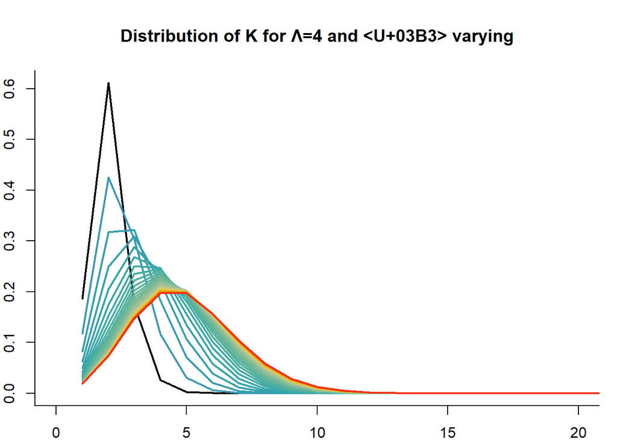

```r
par(mar = c(2,2,4,1), bty = "l")
matplot( t(prob_k), type = "l", lwd = 2,xlim = c(0,20),lty = 1,
          col = c("black",hcl.colors(n=Npoints, palette = "Zissou 1")),
          main = paste0(  paste0( "Distribution of K for \u039B=4 and γ varying") ))
```

Ripeto per $\Lambda = 10$

```r
Npoints = 50
Lambda = 10
gamma_grid  = seq(0.01,1,length.out = Npoints)
prob_k = matrix(nrow = Npoints, ncol = n_j)

for(i in 1:Npoints){

  #threshold = 0.995
  for(kk in 1:max(n_j) ){
    prob_k[i,kk] = p_distinct_prior(k = kk, n_j = n_j,
                                    gamma = c(gamma_grid[i],gamma_grid[i]),
                                    prior = "Poisson",
                                    lambda = Lambda)
    #if(sum(prob_k)>=threshold)
      #break
  }
}
```

La curva nera è la prima, quella con $\gamma$ minore

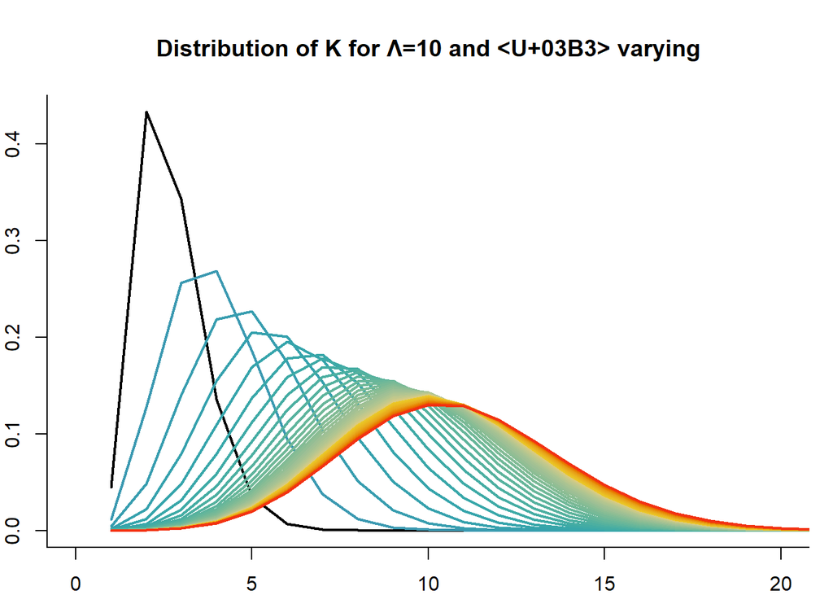

```r
par(mar = c(2,2,4,1), bty = "l")
matplot( t(prob_k), type = "l", lwd = 2,xlim = c(0,20),lty = 1,
          col = c("black",hcl.colors(n=Npoints, palette = "Zissou 1")),
          main = paste0(  paste0( "Distribution of K for \u039B=10 and γ varying") ))
```

## Distribution for $\gamma$ fixed

Ora faccio l’esperimento inverso, tengo fisso $\gamma$ e faccio variare $\Lambda$.

### gamma1 = gamma2 = 2

```r
Npoints = 20
gamma1 <- gamma2 <- 2
Lambda_grid  = seq(1,20,length.out = Npoints)
prob_k3 = matrix(nrow = Npoints, ncol = n_j)

for(i in 1:Npoints){

  #threshold = 0.995
  for(kk in 1:max(n_j) ){
    prob_k3[i,kk] = p_distinct_prior(k = kk, n_j = n_j,
                                     gamma = c(gamma1,gamma2),
                                     prior = "Poisson",
                                     lambda = Lambda_grid[i])
    #if(sum(prob_k)>=threshold)
      #break
  }
}
```

La curva nera è la prima, quella con $\Lambda$ minore. Ogni curva, corrisponde ad aumentare $\Lambda$ di 1.

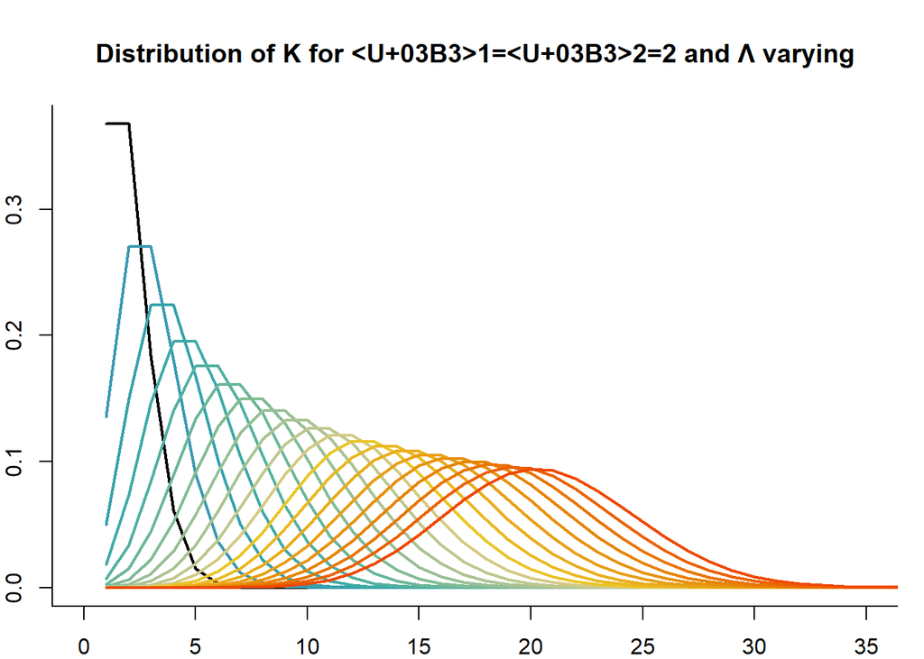

```r
par(mar = c(2,2,4,1), bty = "l")
matplot( t(prob_k3), type = "l", lwd = 2,xlim = c(0,35),lty = 1,
         col = c("black",hcl.colors(n=Npoints, palette = "Zissou 1")),
         main = paste0(  paste0( "Distribution of K for γ1=γ2=2 and \u039B varying") ))
```

### gamma1 = gamma2 = 0.1

Ripeto lo stesso esperimento abbassando il valore di $\gamma_1$ e $\gamma_2$. Ogni curva, corrisponde ad aumentare $\Lambda$ di 1.

```r
Npoints = 20
gamma1 <- gamma2 <- 0.1
Lambda_grid  = seq(1,20,length.out = Npoints)
prob_k4 = matrix(nrow = Npoints, ncol = n_j)

for(i in 1:Npoints){

  #threshold = 0.995
  for(kk in 1:max(n_j) ){
    prob_k4[i,kk] = p_distinct_prior(k = kk, n_j = n_j,
                                     gamma = c(gamma1,gamma2),
                                     prior = "Poisson",
                                     lambda = Lambda_grid[i])
    #if(sum(prob_k)>=threshold)
      #break
  }
}
```

La curva nera è la prima, quella con $\Lambda$ minore. Ogni curva, corrisponde ad aumentare $\Lambda$ di 1.

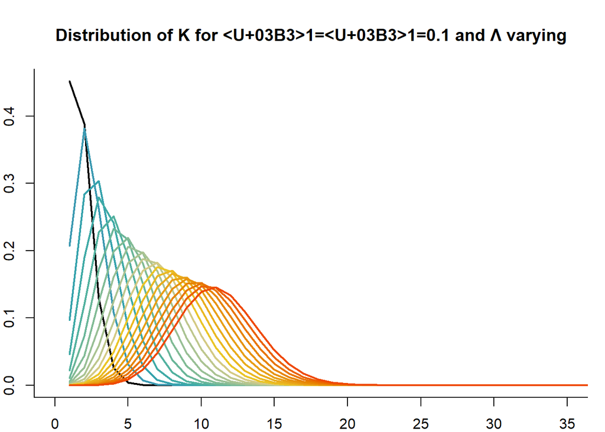

```r
par(mar = c(2,2,4,1), bty = "l")
matplot( t(prob_k4), type = "l", lwd = 2,xlim = c(0,35),lty = 1,
         col = c("black",hcl.colors(n=Npoints, palette = "Zissou 1")),
         main = paste0(  paste0( "Distribution of K for γ1=γ1=0.1 and \u039B varying") ))
```